# Grupo Bimbo Data Exploration

*Objective*: Maximize sales, minimize returns

Planning a celebration is a balancing act of preparing just enough food to go around without being stuck eating the same leftovers for the next week. The key is anticipating how many guests will come. Grupo Bimbo must weigh similar considerations as it strives to meet daily consumer demand for fresh bakery products on the shelves of over 1 million stores along its 45,000 routes across Mexico.

```python
import numpy as np
import pandas as pd
import matplotlib.pyplot as plt
%matplotlib inline
import os
```

```python
clients = pd.read_csv("../input/cliente_tabla.csv", encoding="utf-8")
```

```python
clients.head()
```

|  | Cliente_ID | NombreCliente |
| --- | --- | --- |
| 0 | 0 | SIN NOMBRE |
| 1 | 1 | OXXO XINANTECATL |
| 2 | 2 | SIN NOMBRE |
| 3 | 3 | EL MORENO |
| 4 | 4 | SDN SER DE ALIM CUERPO SA CIA DE INT |

```python
clients.tail()
```

|  | Cliente_ID | NombreCliente |
| --- | --- | --- |
| 935357 | 11011586 | OXXO PETEN |
| 935358 | 11693264 | SUPER ABARROTES MARY |
| 935359 | 19988629 | NO IDENTIFICADO |
| 935360 | 99999999 | NO IDENTIFICADO |
| 935361 | 2015152015 | NO IDENTIFICADO |

```python
len(clients)
```

```
935362
```

```python
products = pd.read_csv("../input/producto_tabla.csv")
```

```python
products.head()
```

|  | Producto_ID | NombreProducto |
| --- | --- | --- |
| 0 | 0 | NO IDENTIFICADO 0 |
| 1 | 9 | Capuccino Moka 750g NES 9 |
| 2 | 41 | Bimbollos Ext sAjonjoli 6p 480g BIM 41 |
| 3 | 53 | Burritos Sincro 170g CU LON 53 |
| 4 | 72 | Div Tira Mini Doradita 4p 45g TR 72 |

```python
products.tail()
```

|  | Producto_ID | NombreProducto |
| --- | --- | --- |
| 2587 | 49992 | Tostado Integral 180g MTA WON 49992 |
| 2588 | 49993 | Tostado Integral 180g TAB WON 49993 |
| 2589 | 49994 | Tostado Int 0pct Grasa Azuc 200g WON 49994 |
| 2590 | 49996 | Tostado Int 0pct Grasa Azuc 200g MTA WON 49996 |
| 2591 | 49997 | Tostado Int 0pct Grasa Azuc 200g TAB WON 49997 |

```python
len(products)
```

```
2592
```

```python
towns = pd.read_csv("../input/town_state.csv")
```

```python
towns.head()
```

|  | Agencia_ID | Town | State |
| --- | --- | --- | --- |
| 0 | 1110 | 2008 AG. LAGO FILT | MÉXICO, D.F. |
| 1 | 1111 | 2002 AG. AZCAPOTZALCO | MÉXICO, D.F. |
| 2 | 1112 | 2004 AG. CUAUTITLAN | ESTADO DE MÉXICO |
| 3 | 1113 | 2008 AG. LAGO FILT | MÉXICO, D.F. |
| 4 | 1114 | 2029 AG.IZTAPALAPA 2 | MÉXICO, D.F. |

```python
towns.tail()
```

|  | Agencia_ID | Town | State |
| --- | --- | --- | --- |
| 785 | 25729 | 2572 TIJUANA EL FLORIDO | BAJA CALIFORNIA NORTE |
| 786 | 25739 | 2573 TIJUANA GATO BRONCO | BAJA CALIFORNIA NORTE |
| 787 | 25749 | 2574 TIJUANA PACIFICO | BAJA CALIFORNIA NORTE |
| 788 | 25759 | 2575 TIJUANA ROSARITO | BAJA CALIFORNIA NORTE |
| 789 | 25769 | 2576 GUERRERO NEGRO | BAJA CALIFORNIA SUR |

```python
towns['State'].unique()
```

```
array(['MÉXICO, D.F.', 'ESTADO DE MÉXICO', 'HIDALGO',
       'Queretaro de Arteaga', 'PUEBLA', 'OAXACA', 'MORELOS', 'GUERRERO',
       'TLAXCALA', 'JALISCO', 'COLIMA', 'ZACATECAS', 'NAYARIT',
       'SAN LUIS POTOSÍ', 'AGUASCALIENTES', 'MICHOACÁN', 'TAMAULIPAS',
       'NUEVO LEÓN', 'COAHUILA', 'CHIHUAHUA', 'DURANGO', 'SONORA',
       'BAJA CALIFORNIA NORTE', 'SINALOA', 'BAJA CALIFORNIA SUR',
       'VERACRUZ', 'GUANAJUATO', 'QUERETARO', 'TABASCO', 'YUCATÁN',
       'CAMPECHE', 'QUINTANA ROO', 'CHIAPAS'], dtype=object)
```

```python
len(towns['Town'].unique())
```

```
260
```

```python
len(towns)
```

```
790
```

```python
train = pd.read_csv("../input/train.csv")
```

```python
train.shape
```

```
(74180464, 11)
```

Reduce the train set to 10% of the total data to reduce the total running time.

```python
train.describe()
```

|  | Semana | Agencia_ID | Canal_ID | Ruta_SAK | Cliente_ID | Producto_ID | Venta_uni_hoy | Venta_hoy | Dev_uni_proxima | Dev_proxima | Demanda_uni_equil |
| --- | --- | --- | --- | --- | --- | --- | --- | --- | --- | --- | --- |
| count | 74180464.000000 | 74180464.000000 | 74180464.000000 | 74180464.000000 | 7.418046e+07 | 74180464.000000 | 74180464.000000 | 74180464.000000 | 74180464.000000 | 74180464.000000 | 74180464.000000 |
| mean | 5.950021 | 2536.508561 | 1.383181 | 2114.855291 | 1.802119e+06 | 20840.813993 | 7.310163 | 68.544523 | 0.130258 | 1.243248 | 7.224564 |
| std | 2.013175 | 4075.123651 | 1.463266 | 1487.744180 | 2.349577e+06 | 18663.919031 | 21.967337 | 338.979516 | 29.323204 | 39.215523 | 21.771193 |
| min | 3.000000 | 1110.000000 | 1.000000 | 1.000000 | 2.600000e+01 | 41.000000 | 0.000000 | 0.000000 | 0.000000 | 0.000000 | 0.000000 |
| 25% | 4.000000 | 1312.000000 | 1.000000 | 1161.000000 | 3.567670e+05 | 1242.000000 | 2.000000 | 16.760000 | 0.000000 | 0.000000 | 2.000000 |
| 50% | 6.000000 | 1613.000000 | 1.000000 | 1286.000000 | 1.193385e+06 | 30549.000000 | 3.000000 | 30.000000 | 0.000000 | 0.000000 | 3.000000 |
| 75% | 8.000000 | 2036.000000 | 1.000000 | 2802.000000 | 2.371091e+06 | 37426.000000 | 7.000000 | 56.100000 | 0.000000 | 0.000000 | 6.000000 |
| max | 9.000000 | 25759.000000 | 11.000000 | 9991.000000 | 2.015152e+09 | 49997.000000 | 7200.000000 | 647360.000000 | 250000.000000 | 130760.000000 | 5000.000000 |

Only look at the most frequent demand adjustments to ignore the outliers in the graphs...

```python
train = train.sample(frac=0.1)
timing = train.loc[train['Demanda_uni_equil'] < 15]
```

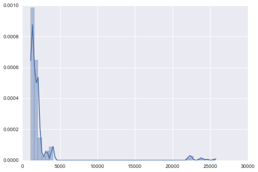

```python
import seaborn as sns
sns.set(color_codes=True)
sns.distplot(timing['Agencia_ID'].values)
```

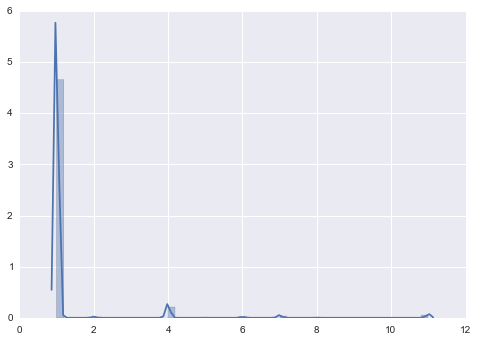

```python
sns.distplot(timing['Canal_ID'].values)
```

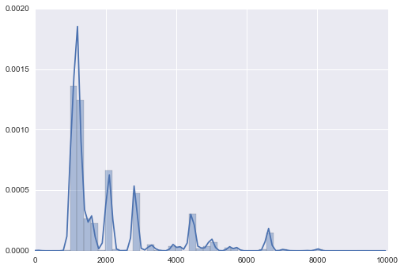

```python
sns.distplot(timing['Ruta_SAK'].values)
```

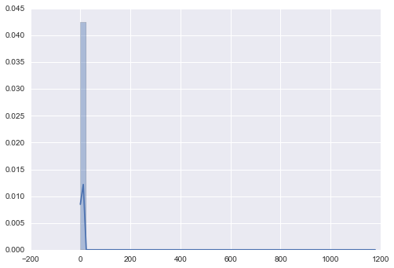

```python
sns.distplot(timing['Venta_uni_hoy'].values)
```

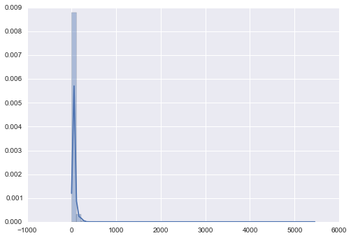

```python
sns.distplot(timing['Venta_hoy'].values)
```

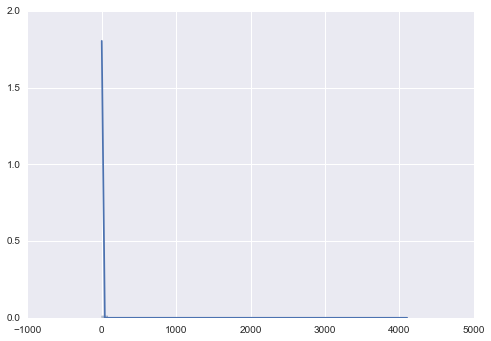

```python
sns.distplot(timing['Dev_uni_proxima'].values)
```

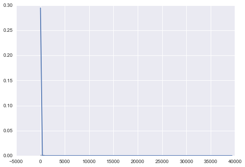

```python
sns.distplot(timing['Dev_proxima'].values)
```

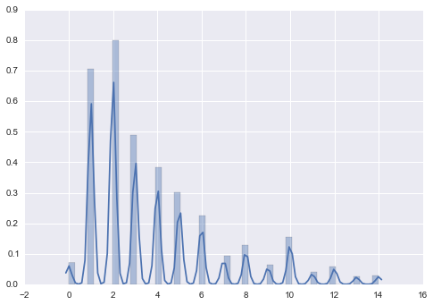

```python
sns.distplot(timing['Demanda_uni_equil'].values)
```

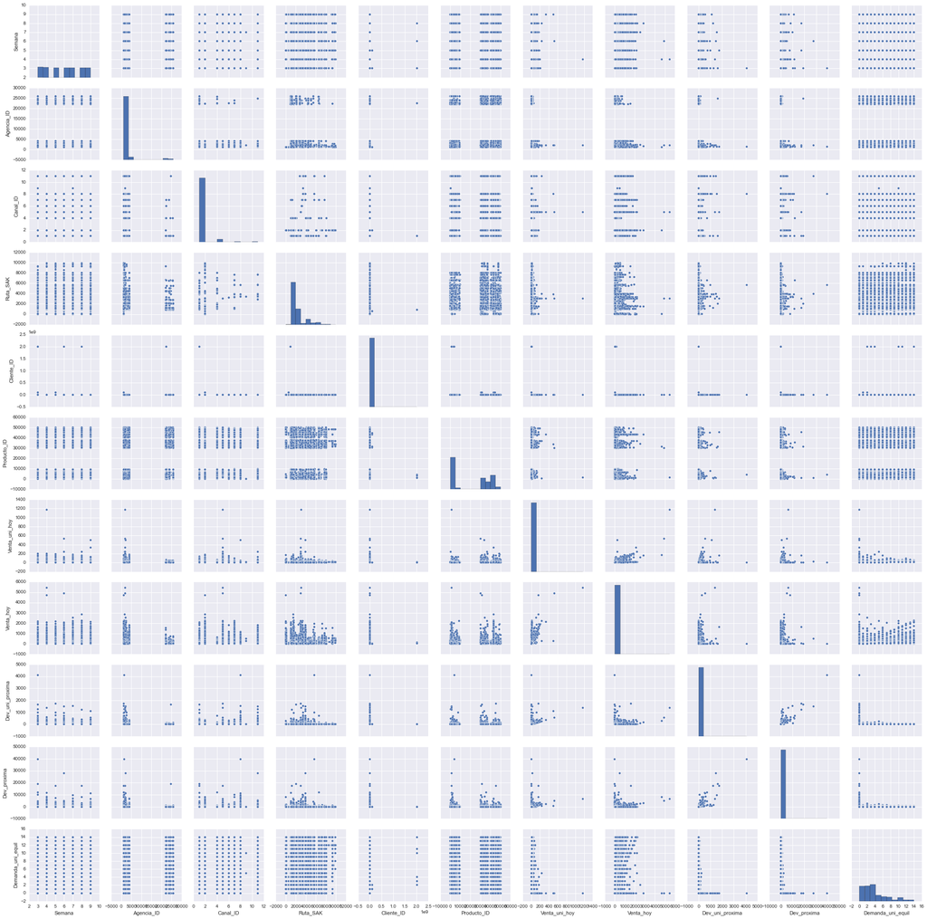

```python
sns.pairplot(timing)
```

# Work on holdout set for CV purposes

```python
test = pd.read_csv("../input/test.csv")
test.drop(['id'], axis=1, inplace=True)
test.shape
```

```
(6999251, 6)
```

```python
train = pd.read_csv("../input/train.csv")
train.drop(['Venta_uni_hoy','Venta_hoy','Dev_uni_proxima','Dev_proxima'], axis=1, inplace=True)
train.shape
```

```
(74180464, 7)
```

```python
test.describe()
```

|  | Semana | Agencia_ID | Canal_ID | Ruta_SAK | Cliente_ID | Producto_ID |
| --- | --- | --- | --- | --- | --- | --- |
| count | 6999251.000000 | 6999251.000000 | 6999251.000000 | 6999251.000000 | 6.999251e+06 | 6999251.000000 |
| mean | 10.494462 | 2504.462764 | 1.401874 | 2138.014097 | 1.819128e+06 | 22163.069696 |
| std | 0.499969 | 4010.228289 | 1.513404 | 1500.391868 | 2.938910e+06 | 18698.156308 |
| min | 10.000000 | 1110.000000 | 1.000000 | 1.000000 | 2.600000e+01 | 41.000000 |
| 25% | 10.000000 | 1311.000000 | 1.000000 | 1159.000000 | 3.558290e+05 | 1242.000000 |
| 50% | 10.000000 | 1612.000000 | 1.000000 | 1305.000000 | 1.200109e+06 | 31507.000000 |
| 75% | 11.000000 | 2034.000000 | 1.000000 | 2804.000000 | 2.387881e+06 | 40930.000000 |
| max | 11.000000 | 25759.000000 | 11.000000 | 9950.000000 | 2.015152e+09 | 49997.000000 |

```python
train.describe()
```

|  | Semana | Agencia_ID | Canal_ID | Ruta_SAK | Cliente_ID | Producto_ID | Demanda_uni_equil |
| --- | --- | --- | --- | --- | --- | --- | --- |
| count | 74180464.000000 | 74180464.000000 | 74180464.000000 | 74180464.000000 | 7.418046e+07 | 74180464.000000 | 74180464.000000 |
| mean | 5.950021 | 2536.508561 | 1.383181 | 2114.855291 | 1.802119e+06 | 20840.813993 | 7.224564 |
| std | 2.013175 | 4075.123651 | 1.463266 | 1487.744180 | 2.349577e+06 | 18663.919031 | 21.771193 |
| min | 3.000000 | 1110.000000 | 1.000000 | 1.000000 | 2.600000e+01 | 41.000000 | 0.000000 |
| 25% | 4.000000 | 1312.000000 | 1.000000 | 1161.000000 | 3.567670e+05 | 1242.000000 | 2.000000 |
| 50% | 6.000000 | 1613.000000 | 1.000000 | 1286.000000 | 1.193385e+06 | 30549.000000 | 3.000000 |
| 75% | 8.000000 | 2036.000000 | 1.000000 | 2802.000000 | 2.371091e+06 | 37426.000000 | 6.000000 |
| max | 9.000000 | 25759.000000 | 11.000000 | 9991.000000 | 2.015152e+09 | 49997.000000 | 5000.000000 |

```python
train.head()
```

|  | Semana | Agencia_ID | Canal_ID | Ruta_SAK | Cliente_ID | Producto_ID | Demanda_uni_equil |
| --- | --- | --- | --- | --- | --- | --- | --- |
| 0 | 3 | 1110 | 7 | 3301 | 15766 | 1212 | 3 |
| 1 | 3 | 1110 | 7 | 3301 | 15766 | 1216 | 4 |
| 2 | 3 | 1110 | 7 | 3301 | 15766 | 1238 | 4 |
| 3 | 3 | 1110 | 7 | 3301 | 15766 | 1240 | 4 |
| 4 | 3 | 1110 | 7 | 3301 | 15766 | 1242 | 3 |

```python
train.tail()
```

|  | Semana | Agencia_ID | Canal_ID | Ruta_SAK | Cliente_ID | Producto_ID | Demanda_uni_equil |
| --- | --- | --- | --- | --- | --- | --- | --- |
| 74180459 | 9 | 25759 | 1 | 5517 | 4528866 | 32873 | 4 |
| 74180460 | 9 | 25759 | 1 | 5517 | 4528866 | 34226 | 4 |
| 74180461 | 9 | 25759 | 1 | 5517 | 4528866 | 45112 | 4 |
| 74180462 | 9 | 25759 | 1 | 5517 | 4547943 | 40217 | 0 |
| 74180463 | 9 | 25759 | 1 | 5517 | 4708097 | 43159 | 1 |

```python
test.head()
```

|  | Semana | Agencia_ID | Canal_ID | Ruta_SAK | Cliente_ID | Producto_ID |
| --- | --- | --- | --- | --- | --- | --- |
| 0 | 11 | 4037 | 1 | 2209 | 4639078 | 35305 |
| 1 | 11 | 2237 | 1 | 1226 | 4705135 | 1238 |
| 2 | 10 | 2045 | 1 | 2831 | 4549769 | 32940 |
| 3 | 11 | 1227 | 1 | 4448 | 4717855 | 43066 |
| 4 | 11 | 1219 | 1 | 1130 | 966351 | 1277 |

```python
def intersect_and_diff(df1,df2,col):
    trainags = set(df1[col].values)
    testags = set(df2[col].values)
    print("intersection: ", len(trainags.intersection(testags)))
    print("train: ", len(trainags))
    print("test: ", len(testags))
    print("difference d1/d2: ", len(trainags.difference(testags)))
    testdiff = testags.difference(trainags)
    print("difference d2/d1: ", len(testdiff))
    return testdiff
```

```python
intersect_and_diff(train,test,'Agencia_ID')
```

```
intersection:  552
train:  552
test:  552
difference d1/d2:  0
difference d2/d1:  0
```

```
set()
```

```python
intersect_and_diff(train,test,'Canal_ID')
print(train['Canal_ID'].value_counts())
print(test['Canal_ID'].value_counts())
```

```
intersection:  9
train:  9
test:  9
difference d1/d2:  0
difference d2/d1:  0
1     67435217
4      3757773
11      982295
2       839496
7       671128
6       281389
5       145818
8        66970
9          378
Name: Canal_ID, dtype: int64
1     6344202
4      364208
11     103951
2       78382
7       60548
6       28023
5       13567
8        6333
9          37
Name: Canal_ID, dtype: int64
```

```python
new_routes = list(intersect_and_diff(train,test,'Ruta_SAK'))
print(new_routes)
```

```
intersection:  2591
train:  3603
test:  2608
difference d1/d2:  1012
difference d2/d1:  17
[7775, 3555, 3556, 3557, 3558, 9349, 6148, 7433, 8044, 4559, 9585, 6162, 3801, 9562, 3803, 8189, 1823]
```

17 new routes in test, 1012 routes in train that do not appear in test

```python
17/3603*100.0
```

```
0.4718290313627533
```

```python
new_clients = list(intersect_and_diff(train,test,'Cliente_ID'))
print(len(new_clients))
```

```
intersection:  735501
train:  880604
test:  745164
difference d1/d2:  145103
difference d2/d1:  9663
9663
```

145103 clients in train that do not appear in test, 9663 new clients that do not appear in train. How many %?

```python
9663/880604 * 100.0
```

```
1.097315024687601
```

```python
new_products = list(intersect_and_diff(train,test,'Producto_ID'))
print(new_products)
```

```
intersection:  1488
train:  1799
test:  1522
difference d1/d2:  311
difference d2/d1:  34
[32026, 37404, 33053, 32798, 37405, 32421, 31655, 36524, 35246, 46131, 32820, 37688, 36673, 37702, 32591, 37202, 42323, 48217, 32224, 98, 31203, 37610, 31211, 46064, 37617, 37362, 37618, 37620, 37745, 37494, 35191, 37495, 37496, 37626]
```

311 products that appear in train, but not in test. 34 new products that do not appear in train. How many %?

```python
34/1799*100.0
```

```
1.8899388549193996
```

**Challenge**: Create a validation set that has similar distributions by stripping out products and clients in a similar fashion. Start with the basics... if predicting 2 weeks as in test, take last 2 weeks:

```python
holdout = train[train['Semana'] > 7]
holdout.describe()
```

|  | Semana | Agencia_ID | Canal_ID | Ruta_SAK | Cliente_ID | Producto_ID | Demanda_uni_equil |
| --- | --- | --- | --- | --- | --- | --- | --- |
| count | 20815581.000000 | 20815581.000000 | 20815581.000000 | 20815581.000000 | 2.081558e+07 | 20815581.000000 | 20815581.000000 |
| mean | 8.500044 | 2505.472726 | 1.396418 | 2114.884483 | 1.809127e+06 | 21261.795478 | 7.233983 |
| std | 0.500000 | 3993.791730 | 1.500743 | 1489.251208 | 2.475499e+06 | 18756.212445 | 21.904491 |
| min | 8.000000 | 1110.000000 | 1.000000 | 1.000000 | 2.600000e+01 | 41.000000 | 0.000000 |
| 25% | 8.000000 | 1311.000000 | 1.000000 | 1158.000000 | 3.553000e+05 | 1242.000000 | 2.000000 |
| 50% | 9.000000 | 1613.000000 | 1.000000 | 1284.000000 | 1.196636e+06 | 30555.000000 | 3.000000 |
| 75% | 9.000000 | 2036.000000 | 1.000000 | 2802.000000 | 2.379737e+06 | 40217.000000 | 6.000000 |
| max | 9.000000 | 25759.000000 | 11.000000 | 9970.000000 | 2.015152e+09 | 49997.000000 | 5000.000000 |

Because agencia and canal are fully intersected, we don't care about those. We do care whether ruta, cliente and producto have similar ratio's of new, unknowns as in test. So we check first:

```python
intersect_and_diff(train,holdout,'Ruta_SAK')
```

```
intersection:  3007
train:  3603
test:  3007
difference d1/d2:  596
difference d2/d1:  0
```

```
set()
```

```python
intersect_and_diff(train,holdout,'Cliente_ID')
```

```
intersection:  810657
train:  880604
test:  810657
difference d1/d2:  69947
difference d2/d1:  0
```

```
set()
```

```python
intersect_and_diff(train,holdout,'Producto_ID')
```

```
intersection:  1634
train:  1799
test:  1634
difference d1/d2:  165
difference d2/d1:  0
```

```
set()
```

Let's figure out the statistics for the test dataset where it concerns new routes:

```python
routes = test[test['Ruta_SAK'].isin(new_routes)]
routes.describe()
```

|  | Semana | Agencia_ID | Canal_ID | Ruta_SAK | Cliente_ID | Producto_ID |
| --- | --- | --- | --- | --- | --- | --- |
| count | 295.000000 | 295.000000 | 295.000000 | 295.000000 | 295.000000 | 295.000000 |
| mean | 10.796610 | 2000.996610 | 5.237288 | 4101.189831 | 4379144.372881 | 22028.389831 |
| std | 0.403204 | 780.784106 | 4.346157 | 1046.100331 | 1213602.296783 | 18233.531843 |
| min | 10.000000 | 1314.000000 | 1.000000 | 1823.000000 | 60.000000 | 73.000000 |
| 25% | 11.000000 | 1524.000000 | 1.000000 | 3558.000000 | 4718025.000000 | 1250.000000 |
| 50% | 11.000000 | 2020.000000 | 2.000000 | 3803.000000 | 4735949.000000 | 31187.000000 |
| 75% | 11.000000 | 2020.000000 | 11.000000 | 4559.000000 | 4758328.000000 | 37058.000000 |
| max | 11.000000 | 4035.000000 | 11.000000 | 9585.000000 | 9656377.000000 | 48421.000000 |

295 records from test, most of them in the last week. So let's select 17 routes from holdout that mostly occur in week 9.

```python
routes['Ruta_SAK'].value_counts()
```

```
4559    123
3801     41
3558     40
3556     21
3803     18
3557     17
1823     15
3555      9
9585      2
6162      2
8189      1
9349      1
7775      1
9562      1
7433      1
8044      1
6148      1
Name: Ruta_SAK, dtype: int64
```

```python
def select_random(a, num):
    index_array = np.arange(len(a))
    np.random.shuffle(index_array)
    return a[index_array[:num]]
```

```python
lesscols = holdout[["Ruta_SAK", "Semana"]]
subset = lesscols.groupby("Ruta_SAK").filter(lambda x: len(x) == 1)
a = subset["Ruta_SAK"].unique()
select_random(a, 7)
```

```
array([8717, 8029, 8319, 9299, 9712, 9842, 3090])
```

```python
subset = lesscols.groupby("Ruta_SAK").filter(lambda x: len(x) == 2)
a = subset["Ruta_SAK"].unique()
select_random(a, 2)
```

```
array([7878, 9078])
```

```python
subset = lesscols.groupby("Ruta_SAK").filter(lambda x: len(x) > 15 and len(x) < 22)
a = subset["Ruta_SAK"].unique()
select_random(a, 5)
```

```
array([7716, 8501, 7438, 8113, 1000])
```

```python
subset = lesscols.groupby("Ruta_SAK").filter(lambda x: len(x) > 38 and len(x) < 42)
a = subset["Ruta_SAK"].unique()
select_random(a, 2)
```

```
array([7239, 7258])
```

```python
subset = lesscols.groupby("Ruta_SAK").filter(lambda x: len(x) > 115 and len(x) < 125)
a = subset["Ruta_SAK"].unique()
select_random(a, 1)
```

```
array([72])
```

```python
routes_holdout = [8717, 8029, 8319, 9299, 9712, 9842, 3090, 7878, 9078, 7716, 8501, 7438, 8113, 1000, 7239, 7258, 72]
```

```python
delroutes = train[train['Ruta_SAK'].isin(routes_holdout)]
delroutes.describe()
```

|  | Semana | Agencia_ID | Canal_ID | Ruta_SAK | Cliente_ID | Producto_ID | Demanda_uni_equil |
| --- | --- | --- | --- | --- | --- | --- | --- |
| count | 1054.000000 | 1054.000000 | 1054.000000 | 1054.000000 | 1054.000000 | 1054.000000 | 1054.000000 |
| mean | 6.013283 | 1564.886148 | 2.489564 | 4307.454459 | 1290097.412713 | 36273.938330 | 226.198292 |
| std | 1.991867 | 450.468487 | 1.285238 | 3780.782587 | 1580182.231569 | 9142.896611 | 489.022938 |
| min | 3.000000 | 1114.000000 | 2.000000 | 72.000000 | 60.000000 | 53.000000 | 0.000000 |
| 25% | 4.000000 | 1114.000000 | 2.000000 | 72.000000 | 19181.000000 | 33682.000000 | 12.000000 |
| 50% | 6.000000 | 1452.000000 | 2.000000 | 7239.000000 | 1093627.000000 | 35148.000000 | 32.000000 |
| 75% | 8.000000 | 2061.000000 | 2.000000 | 7438.000000 | 1379288.000000 | 43173.000000 | 137.250000 |
| max | 9.000000 | 2655.000000 | 8.000000 | 9842.000000 | 5977226.000000 | 49028.000000 | 3726.000000 |

```python
clients = test[test['Cliente_ID'].isin(new_clients)]
clients.describe()
```

|  | Semana | Agencia_ID | Canal_ID | Ruta_SAK | Cliente_ID | Producto_ID |
| --- | --- | --- | --- | --- | --- | --- |
| count | 30054.000000 | 30054.000000 | 30054.000000 | 30054.000000 | 30054.000000 | 30054.000000 |
| mean | 10.626206 | 2438.713815 | 1.801391 | 2759.347308 | 4044029.768550 | 24972.109470 |
| std | 0.483818 | 3783.984425 | 2.472351 | 1560.479222 | 1455360.698733 | 18099.335298 |
| min | 10.000000 | 1110.000000 | 1.000000 | 900.000000 | 2683.000000 | 72.000000 |
| 25% | 10.000000 | 1315.000000 | 1.000000 | 1256.000000 | 4375287.000000 | 1284.000000 |
| 50% | 11.000000 | 1621.000000 | 1.000000 | 2808.000000 | 4746758.000000 | 34206.000000 |
| 75% | 11.000000 | 2036.000000 | 1.000000 | 3901.000000 | 4760485.000000 | 41938.000000 |
| max | 11.000000 | 25759.000000 | 11.000000 | 8056.000000 | 9780515.000000 | 49986.000000 |

```python
clients['Cliente_ID'].value_counts()[:60]
```

```
4727099    45
142903     36
4760228    34
4766630    32
4761419    32
1999197    31
4750139    29
487983     28
1439838    28
4718024    27
4762015    27
4758816    27
478662     27
24187      26
4706068    26
```

[output cut: 46 more lines]

```python
clients['Cliente_ID'].value_counts()[-20:]
```

```
987962     1
4764462    1
4725403    1
4768432    1
4767932    1
4743860    1
4758219    1
4698830    1
1944276    1
4548862    1
4760673    1
4391108    1
1729300    1
4758299    1
305949     1
4545315    1
289573     1
4752168    1
4754217    1
2426881    1
Name: Cliente_ID, dtype: int64
```

There are more clients than routes, so we're going to use some tricks to append to the list of clients to exclude. We're taking clients from several bins of 10-wide. The following statement allows us to figure out how many clients to select at random.

```python
subset = clients.groupby("Cliente_ID").filter(lambda x: len(x) < 11 and len(x) > 1)
len(subset["Cliente_ID"].unique())
```

[output not shown]

So let's start with an empty list and add clients of interest to those. The reason we take from bins is that the number of clients that appear once or twice is much larger, so a random pick wouldn't get the same ratio.

```python
clients_holdout = []
```

```python
lesscols = holdout[["Cliente_ID", "Semana"]]
subset = lesscols.groupby("Cliente_ID").filter(lambda x: len(x) == 45)
a = subset["Cliente_ID"].unique()
clients_holdout.extend(select_random(a, 1).tolist())
print(len(clients_holdout))
```

[output not shown]

```python
subset = lesscols.groupby("Cliente_ID").filter(lambda x: len(x) < 36 and len(x) > 30)
a = subset["Cliente_ID"].unique()
# 5 from this range
clients_holdout.extend(select_random(a, 5).tolist())
print(len(clients_holdout))
```

```
6
```

```python
subset = lesscols.groupby("Cliente_ID").filter(lambda x: len(x) < 31 and len(x) > 20)
a = subset["Cliente_ID"].unique()
# 38 from 20-30
clients_holdout.extend(select_random(a, 38).tolist())
print(len(clients_holdout))
```

```
44
```

```python
subset = lesscols.groupby("Cliente_ID").filter(lambda x: len(x) < 21 and len(x) > 10)
a = subset["Cliente_ID"].unique()
# 289 from 10-20
clients_holdout.extend(select_random(a, 289).tolist())
print(len(clients_holdout))
```

```
333
```

```python
subset = lesscols.groupby("Cliente_ID").filter(lambda x: len(x) < 11 and len(x) > 1)
a = subset["Cliente_ID"].unique()
# 2-10
clients_holdout.extend(select_random(a, 5513).tolist())
print(len(clients_holdout))
```

```
5846
```

```python
subset = lesscols.groupby("Cliente_ID").filter(lambda x: len(x) < 2)
a = subset["Cliente_ID"].unique()
# < 2
clients_holdout.extend(select_random(a, 3817).tolist())
print(len(clients_holdout))
```

[output not shown]

```python
subset = clients.groupby("Cliente_ID").filter(lambda x: len(x) < 2)
len(subset["Cliente_ID"].unique())
```

```
3817
```

```python
delclients = train[train['Cliente_ID'].isin(clients_holdout)]
delclients.describe()
```

|  | Semana | Agencia_ID | Canal_ID | Ruta_SAK | Cliente_ID | Producto_ID | Demanda_uni_equil |
| --- | --- | --- | --- | --- | --- | --- | --- |
| count | 185005.000000 | 185005.000000 | 185005.000000 | 185005.000000 | 185005.000000 | 185005.000000 | 185005.000000 |
| mean | 5.672603 | 2750.070171 | 1.794152 | 2357.628653 | 2510979.371860 | 21559.627626 | 5.640556 |
| std | 1.952651 | 4496.915716 | 2.486566 | 1380.786953 | 1863765.610121 | 18723.008556 | 29.901464 |
| min | 3.000000 | 1110.000000 | 1.000000 | 900.000000 | 2083.000000 | 53.000000 | 0.000000 |
| 25% | 4.000000 | 1347.000000 | 1.000000 | 1226.000000 | 969798.000000 | 1250.000000 | 1.000000 |
| 50% | 6.000000 | 1636.000000 | 1.000000 | 2012.000000 | 2100301.000000 | 30572.000000 | 2.000000 |
| 75% | 7.000000 | 2040.000000 | 1.000000 | 2856.000000 | 4376614.000000 | 41843.000000 | 5.000000 |
| max | 9.000000 | 25759.000000 | 11.000000 | 8061.000000 | 9746158.000000 | 49990.000000 | 4340.000000 |

```python
print(len(clients_holdout))
with open("../input/clients.txt", "w") as outfile:
    outfile.write("\n".join(str(x) for x in clients_holdout))
```

```
9663
```

```python
prods = test[test['Producto_ID'].isin(new_products)]
prods.describe()
```

|  | Semana | Agencia_ID | Canal_ID | Ruta_SAK | Cliente_ID | Producto_ID |
| --- | --- | --- | --- | --- | --- | --- |
| count | 25640.000000 | 25640.000000 | 25640.000000 | 25640.000000 | 25640.000000 | 25640.000000 |
| mean | 10.929758 | 2486.820593 | 1.034360 | 2971.128042 | 1819638.332488 | 37581.493019 |
| std | 0.255559 | 3826.057086 | 0.578848 | 1344.679103 | 1850379.387033 | 1705.408887 |
| min | 10.000000 | 1110.000000 | 1.000000 | 900.000000 | 2073.000000 | 98.000000 |
| 25% | 11.000000 | 1347.000000 | 1.000000 | 2007.000000 | 352437.500000 | 37202.000000 |
| 50% | 11.000000 | 1550.000000 | 1.000000 | 2808.000000 | 1186456.000000 | 37495.000000 |
| 75% | 11.000000 | 2014.000000 | 1.000000 | 4410.000000 | 2395403.750000 | 37495.000000 |
| max | 11.000000 | 25759.000000 | 11.000000 | 8003.000000 | 9753668.000000 | 48217.000000 |

```python
prods['Producto_ID'].value_counts()
```

```
37495    16443
37202     5062
36673     1828
46131      826
37494      590
32421      232
37404      198
37496      154
32820      126
37626       51
37688       35
36524       25
37362       25
31203       16
37405        4
```

[output cut: 20 more lines]

```python
prods_holdout = []
```

```python
lesscols = holdout[["Producto_ID", "Semana"]]
subset = lesscols.groupby("Producto_ID").filter(lambda x: len(x) > 15000)
a = subset["Producto_ID"].unique()
np.set_printoptions(threshold=20)
prods_holdout.extend(select_random(a, 1).tolist())
```

```python
subset = lesscols.groupby("Producto_ID").filter(lambda x: len(x) < 5200 and len(x) > 4800)
a = subset["Producto_ID"].unique()
prods_holdout.extend(select_random(a, 1).tolist())
```

```python
subset = lesscols.groupby("Producto_ID").filter(lambda x: len(x) < 1900 and len(x) > 1700)
a = subset["Producto_ID"].unique()
prods_holdout.extend(select_random(a, 1).tolist())
```

```python
subset = lesscols.groupby("Producto_ID").filter(lambda x: len(x) < 900 and len(x) > 800)
a = subset["Producto_ID"].unique()
prods_holdout.extend(select_random(a, 1).tolist())
```

```python
subset = lesscols.groupby("Producto_ID").filter(lambda x: len(x) < 600 and len(x) > 500)
a = subset["Producto_ID"].unique()
prods_holdout.extend(select_random(a, 1).tolist())
```

```python
subset = lesscols.groupby("Producto_ID").filter(lambda x: len(x) < 200 and len(x) > 100)
a = subset["Producto_ID"].unique()
prods_holdout.extend(select_random(a, 4).tolist())
```

```python
subset = lesscols.groupby("Producto_ID").filter(lambda x: len(x) < 50 and len(x) > 15)
a = subset["Producto_ID"].unique()
prods_holdout.extend(select_random(a, 5).tolist())
```

```python
subset = lesscols.groupby("Producto_ID").filter(lambda x: len(x) < 3)
a = subset["Producto_ID"].unique()
prods_holdout.extend(select_random(a, 7).tolist())
```

```python
print(prods_holdout)
```

```
[43307, 36964, 43027, 6490, 32863, 31771, 31201, 31006, 35072, 30177, 45565, 40297, 46195, 46215, 35095, 37469, 2063, 49997, 48250, 33208, 37191]
```

```python
delprods = train[train['Producto_ID'].isin(prods_holdout)]
delprods.describe()
```

|  | Semana | Agencia_ID | Canal_ID | Ruta_SAK | Cliente_ID | Producto_ID | Demanda_uni_equil |
| --- | --- | --- | --- | --- | --- | --- | --- |
| count | 543368.000000 | 543368.000000 | 543368.000000 | 543368.000000 | 543368.000000 | 543368.000000 | 543368.000000 |
| mean | 6.060578 | 3036.052826 | 1.451871 | 3117.965716 | 1978859.383396 | 42674.865542 | 13.309599 |
| std | 2.002447 | 4676.810918 | 1.632218 | 1198.892360 | 1930768.791755 | 3285.255157 | 23.720843 |
| min | 3.000000 | 1110.000000 | 1.000000 | 1.000000 | 65.000000 | 2063.000000 | 0.000000 |
| 25% | 4.000000 | 1462.000000 | 1.000000 | 2034.000000 | 480309.000000 | 43307.000000 | 4.000000 |
| 50% | 6.000000 | 1614.000000 | 1.000000 | 2824.000000 | 1404869.000000 | 43307.000000 | 7.000000 |
| 75% | 8.000000 | 2213.000000 | 1.000000 | 4137.000000 | 2472109.000000 | 43307.000000 | 13.000000 |
| max | 9.000000 | 25759.000000 | 11.000000 | 9921.000000 | 10351814.000000 | 49997.000000 | 1621.000000 |

```python
train = train[~train['Producto_ID'].isin(prods_holdout)]
```

```python
train = train[~train['Cliente_ID'].isin(clients_holdout)]
```

```python
train = train[~train['Ruta_SAK'].isin(routes_holdout)]
```

```python
len(intersect_and_diff(train,holdout,'Ruta_SAK'))
```

```
intersection:  2989
train:  3580
test:  3007
difference d1/d2:  591
difference d2/d1:  18
```

```
18
```

```python
len(intersect_and_diff(train,holdout,'Cliente_ID'))
```

```
intersection:  800798
train:  870385
test:  810657
difference d1/d2:  69587
difference d2/d1:  9859
```

```
9859
```

```python
len(intersect_and_diff(train,holdout,'Producto_ID'))
```

```
intersection:  1613
train:  1778
test:  1634
difference d1/d2:  165
difference d2/d1:  21
```

```
21
```